# Impacto del transporte entre la residencia del alumno y la universidad en su tiempo efectivo de trabajo y rendimiento académico

### Regresión

**1. Horas de Sueño diarias en función del Nivel de Estrés**

```r
Estres_Sueño=lm(DF$Tiempo_Dormir~DF$Estres)
summary(Estres_Sueño)
```

```
##
## Call:
## lm(formula = DF$Tiempo_Dormir ~ DF$Estres)
##
## Residuals:
##     Min      1Q  Median      3Q     Max
## -3.2642 -0.7333 -0.1111  0.8889  2.2667
##
## Coefficients:
##             Estimate Std. Error t value Pr(>|t|)
## (Intercept)   6.8667     0.2047  33.541  < 2e-16 ***
## DF$EstresB   -0.7556     0.2553  -2.959  0.00351 **
## DF$EstresC   -0.6025     0.2562  -2.352  0.01980 *
## DF$EstresD   -0.8667     0.2946  -2.941  0.00371 **
## DF$EstresE   -1.1333     0.3546  -3.196  0.00165 **
## ---
## Signif. codes:  0 '***' 0.001 '**' 0.01 '*' 0.05 '.' 0.1 ' ' 1
##
## Residual standard error: 1.121 on 175 degrees of freedom
## Multiple R-squared:  0.07626,    Adjusted R-squared:  0.05514
## F-statistic: 3.612 on 4 and 175 DF,  p-value: 0.007423
```

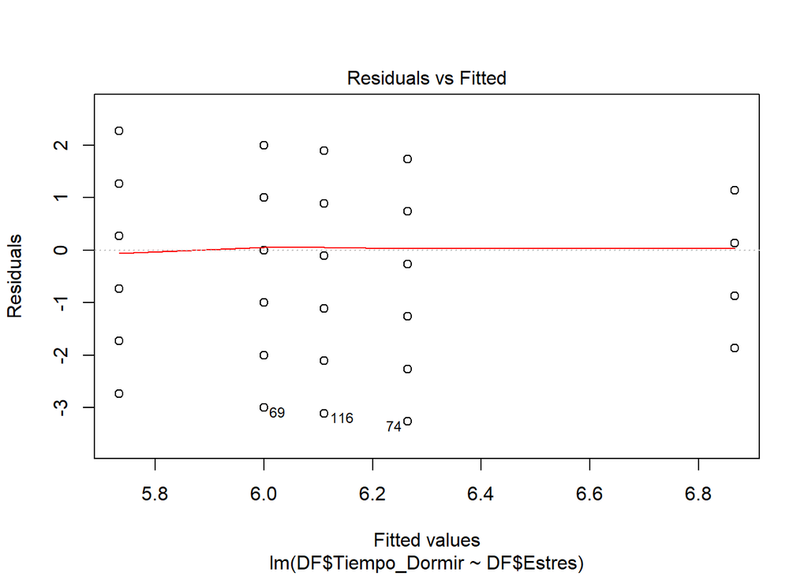

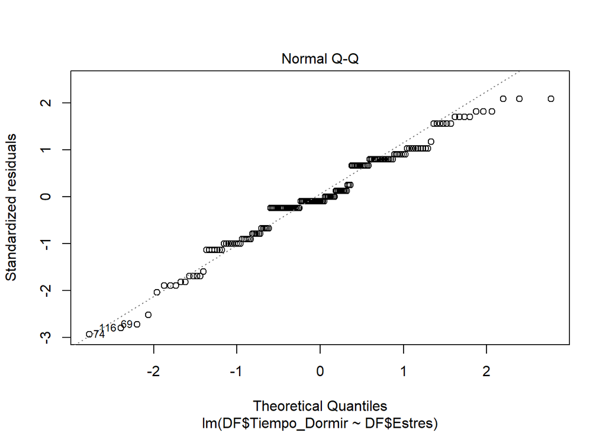

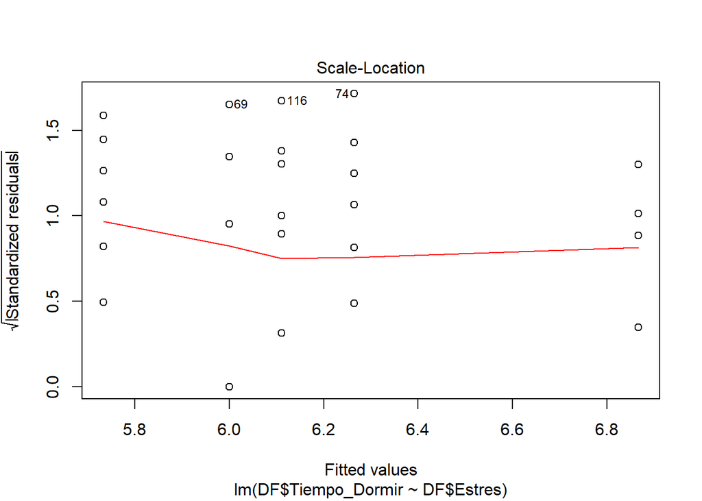

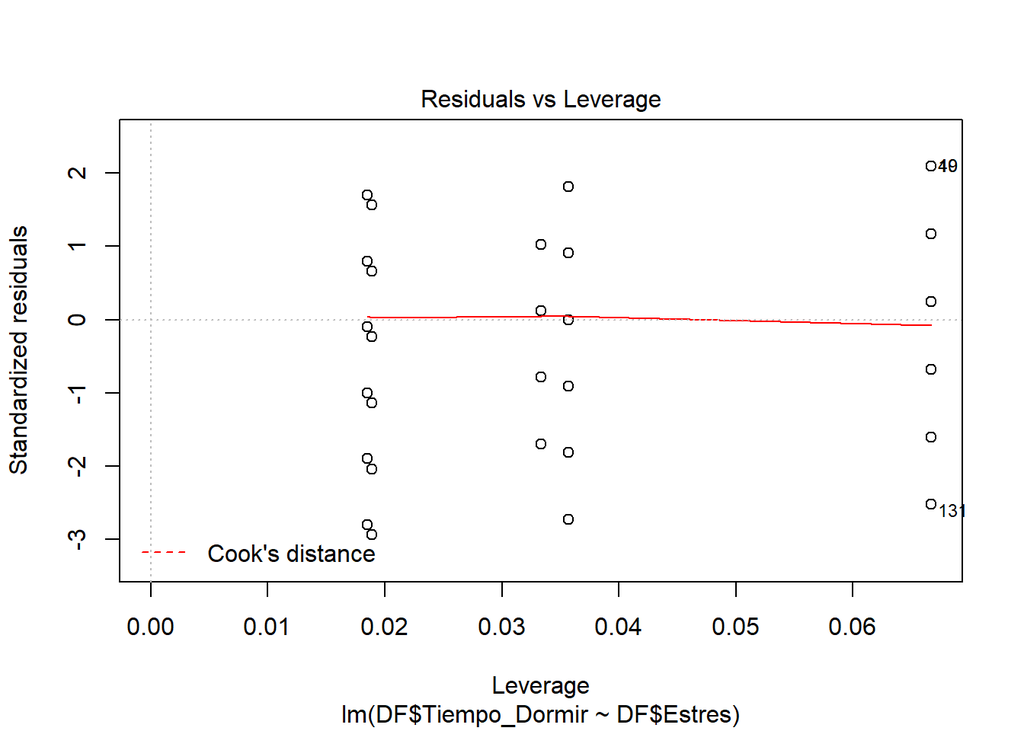

```r
plot(Estres_Sueño)
```

**2. Número de Cursos desaprobados en función del Tiempo de Transporte diario**

```r
Trans_Repr=lm(DF$NroReprobados~DF$Tiempo_Transporte)
summary(Trans_Repr)
```

```
##
## Call:
## lm(formula = DF$NroReprobados ~ DF$Tiempo_Transporte)
##
## Residuals:
##      Min       1Q   Median       3Q      Max
## -0.44239 -0.31697 -0.27517 -0.03771  1.76107
##
## Coefficients:
##                       Estimate Std. Error t value Pr(>|t|)
## (Intercept)          0.2333601  0.0766166   3.046  0.00267 **
## DF$Tiempo_Transporte 0.0006968  0.0006155   1.132  0.25912
## ---
## Signif. codes:  0 '***' 0.001 '**' 0.01 '*' 0.05 '.' 0.1 ' ' 1
##
## Residual standard error: 0.5697 on 178 degrees of freedom
## Multiple R-squared:  0.007149,   Adjusted R-squared:  0.001571
## F-statistic: 1.282 on 1 and 178 DF,  p-value: 0.2591
```

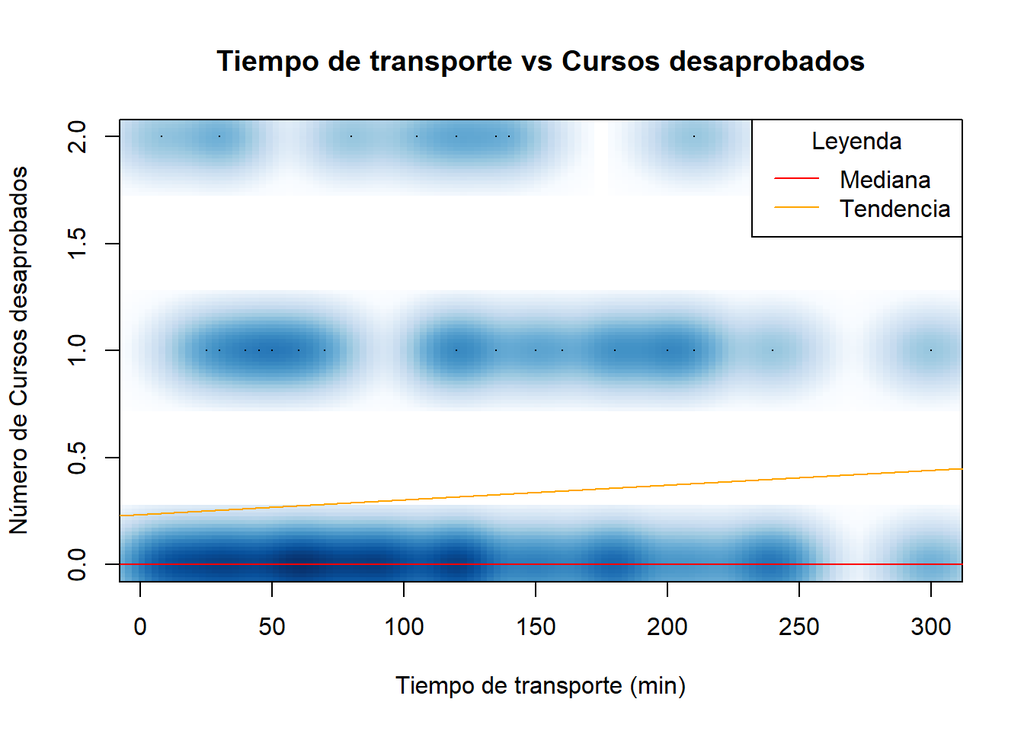

```r
smoothScatter(DF$Tiempo_Transporte,DF$NroReprobados,xlab= "Tiempo de transporte (min)",ylab="Número de Cursos desaprobados",main="Tiempo de transporte vs Cursos desaprobados")
abline(h=median(DF$NroReprobados),col="red")
abline(Trans_Repr, col='orange')
legend("topright", c("Mediana", "Tendencia"),lty=c(1, 1), col=c("red","orange"),title="Leyenda",bg="white")
```

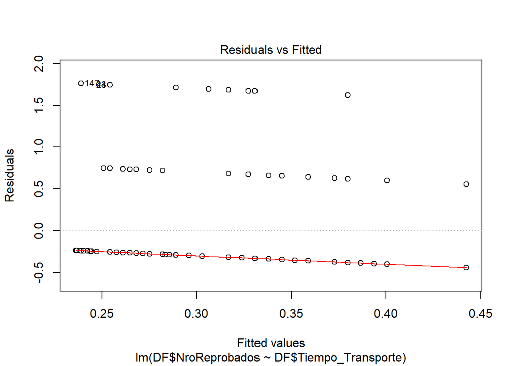

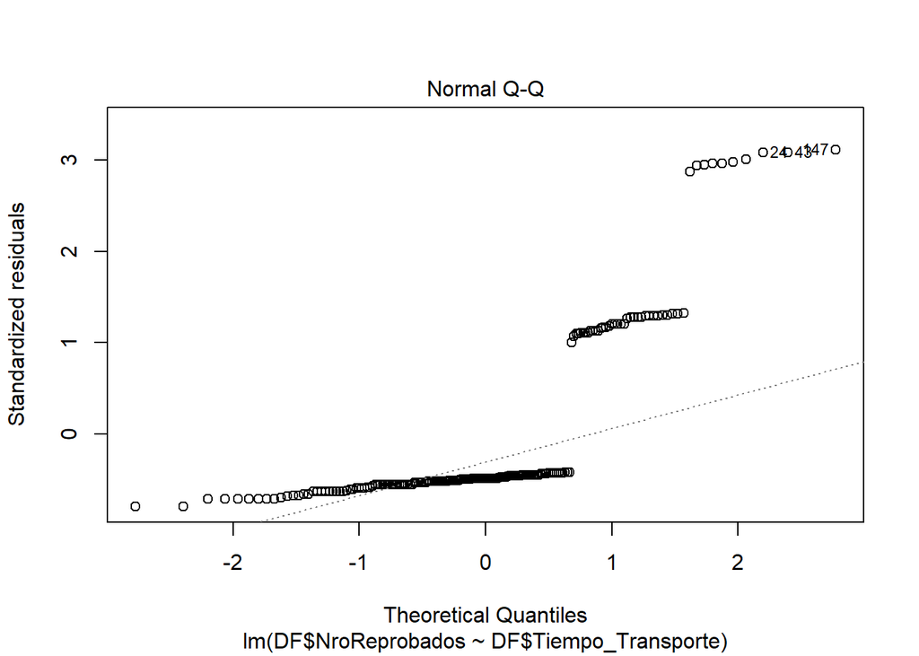

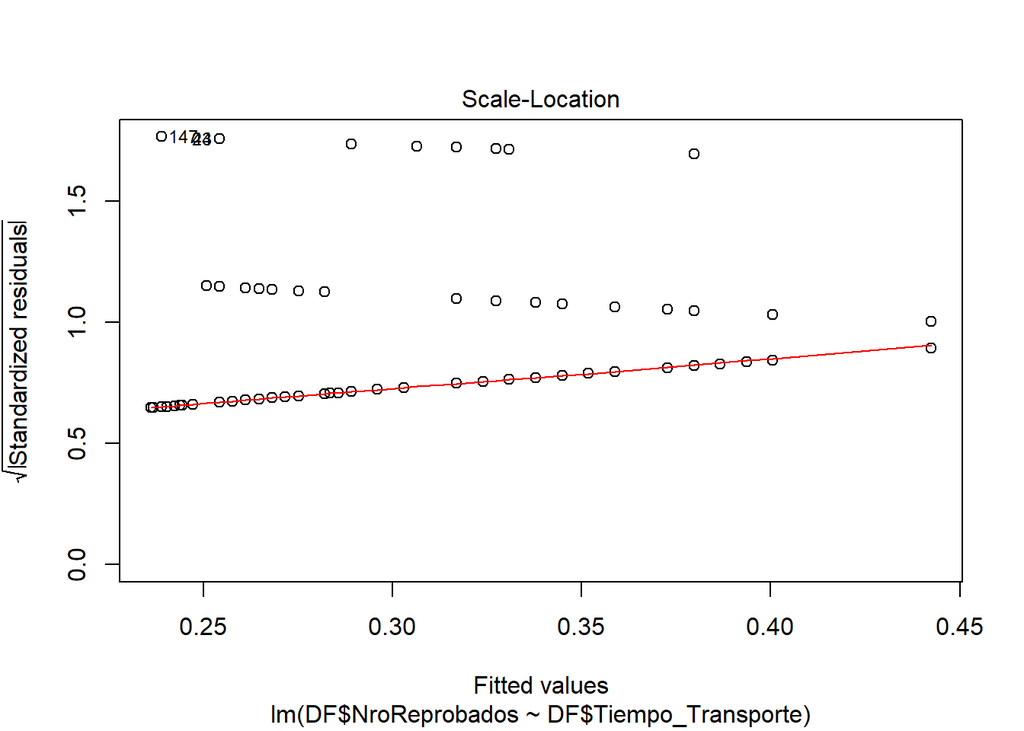

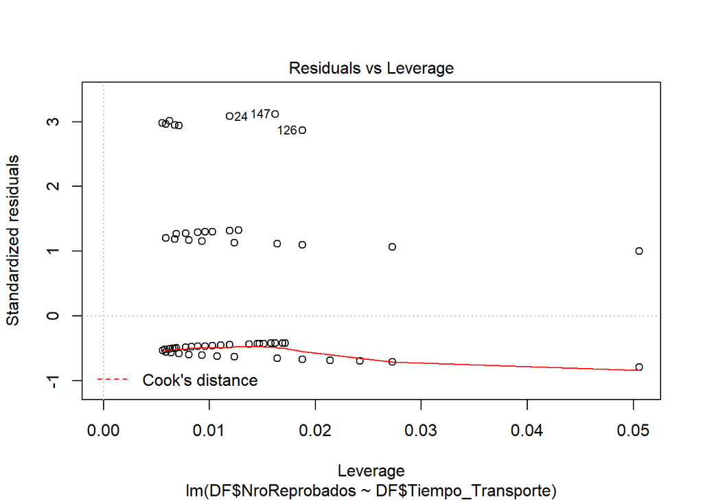

```r
plot(Trans_Repr)
```

**Análisis**

Al analizar el modelo obtenido se observa un p.value igual a 0.2591, por lo que al ser mayor a la significancia no se rechaza la hipótesis nula, que es la no dependencia del número de reprobados con respecto al tiempo de transporte diario. Asimismo, al observar la tendencia (resultado de la regresión) en el gráfico y la heterocedasticidad en los residuos del modelo se respalda el no rechazo a la hipótesis nula y se concluye que el número de cursos reprobados por el estudiante es independiente del tiempo de transporte diario.

**3. Horas de Sueño diarias en función del Tiempo de Transporte Semanal**

```r
Trans_Sueño=lm(DF$Tiempo_Dormir~DF$Transporte_Semanal)
summary(Trans_Sueño)
```

```
##
## Call:
## lm(formula = DF$Tiempo_Dormir ~ DF$Transporte_Semanal)
##
## Residuals:
##     Min      1Q  Median      3Q     Max
## -3.5199 -0.5296 -0.0410  0.7887  2.0334
##
## Coefficients:
##                         Estimate Std. Error t value Pr(>|t|)
## (Intercept)            6.6049783  0.1480073  44.626  < 2e-16 ***
## DF$Transporte_Semanal -0.0007094  0.0002325  -3.051  0.00263 **
## ---
## Signif. codes:  0 '***' 0.001 '**' 0.01 '*' 0.05 '.' 0.1 ' ' 1
##
## Residual standard error: 1.128 on 178 degrees of freedom
## Multiple R-squared:  0.04969,    Adjusted R-squared:  0.04435
## F-statistic: 9.307 on 1 and 178 DF,  p-value: 0.002633
```

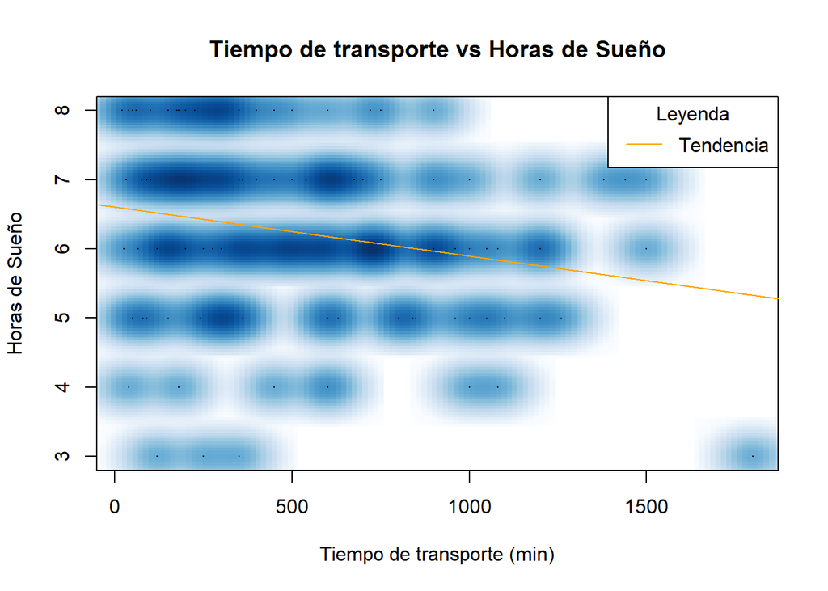

```r
smoothScatter(DF$Transporte_Semanal,DF$Tiempo_Dormir,xlab= "Tiempo de transporte (min)",ylab="Horas de Sueño",main="Tiempo de transporte vs Horas de Sueño")
abline(Trans_Sueño, col='orange')
legend("topright", c("Tendencia"),lty=c(1, 1), col=c("orange"),title="Leyenda",bg="white")
```

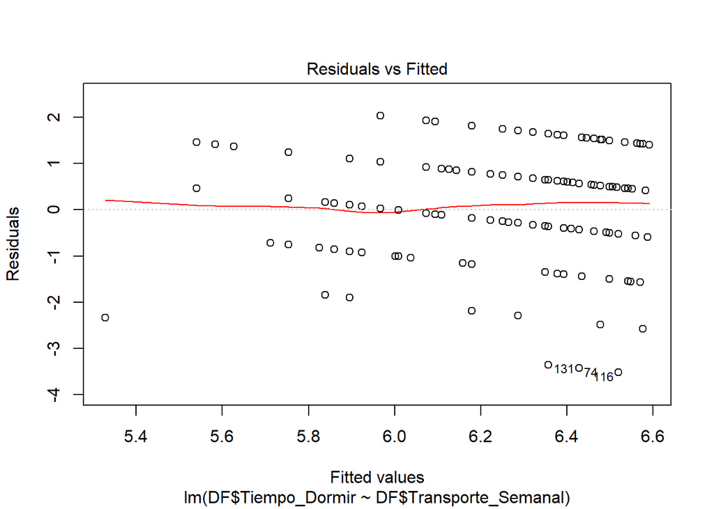

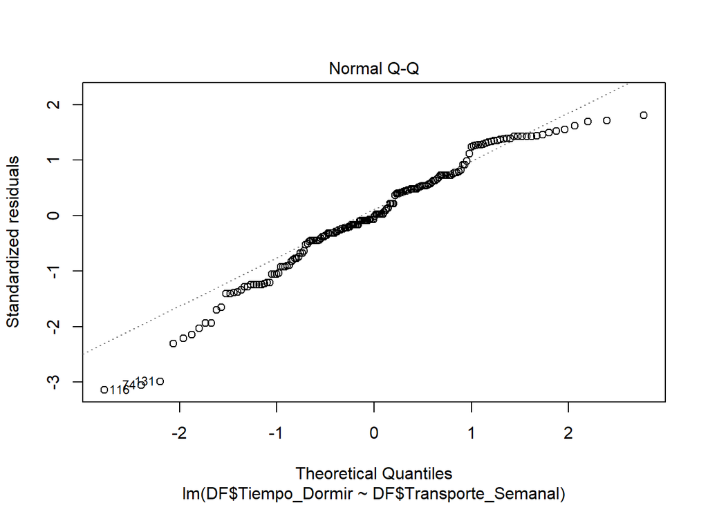

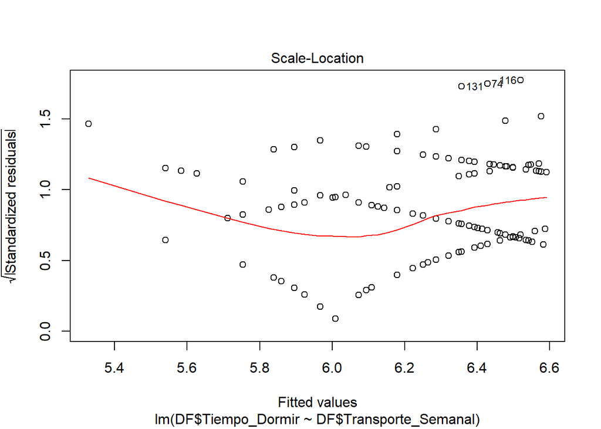

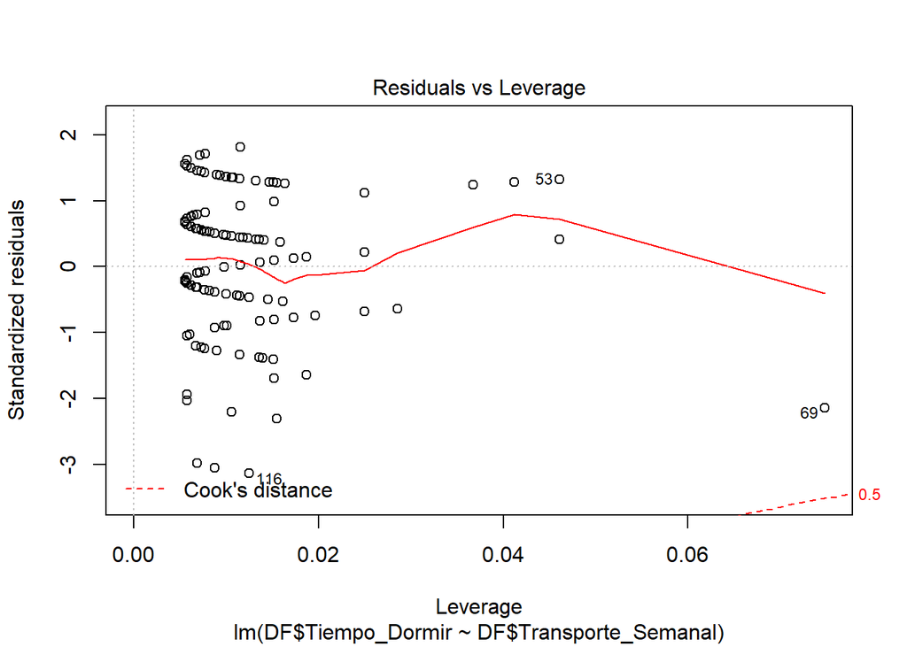

```r
plot(Trans_Sueño)
```